# Predicted seagrass carbon map at Ria de Aveiro for 2024 and 2025

Lee, Chengfa Benjamin

2026-03-12

This page documents the results of the *Zostera noltii* seagrass carbon mapping work at Ria de Aviero. This includes work done in:

- [The fieldtrip of Aveiro 2025](https://sigoiry.github.io/Spectra_Aveiro_2025/) by [Simon Oiry](https://github.com/SigOiry)
- [Coring Carbon Seagrass](https://sigoiry.github.io/Coring_Carbon_Seagrasses/) by Simon Oiry
- [Exploring the relationship between seagrass reflectance and biomass](https://leechengfa.github.io/Seagrass_reflectance_biomass_2025.github.io/)
- [Measuring the carbon content in *Zostera noltii* seagrass](https://leechengfa.github.io/seagrass_carbon_2025/)

All analyses were performed in R version 4.5.2 (R Core Team 2025). All work belong to the [REWRITE project](https://rewriteproject.eu/).

# 1 Study Location

This page focuses on Ria de Aveiro, a [demonstrator site for the REWRITE PROJECT](https://rewriteproject.eu/demonstrator-network/ria-de-aveiro). A natural site and rewilded site was designated in the lagoon and seagrass meadows were found in both sites. Its seagrass meadow was estimated to be 3.52 km<sup>2</sup> during the peak season of 2024 (Davies et al. 2024).

The sites were sampled according to a grid, and additional stations were sampled randomly within the grid.

[interactive chart not shown]

# 2 Seasonal change in NDVI

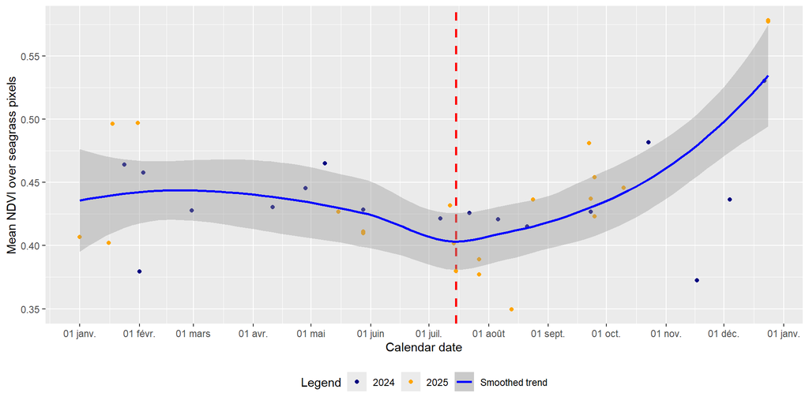

The intertidal masks were digitised using QGIS according to the published maps detailing the seagrass areas A to P reported in Sousa et al. (2019). An additional polygon for the rewilded island was included in the mask.

# 3 ICE CREAMS Model prediction

For the purpose of map display and data analysis, the result from the Sentinel-2 image on 15 July 2025 was chosen. This date falls within the fieldwork dates and is thus best for validation and groundtruthing.

[interactive chart not shown]

# 4 Biomass prediction

[interactive chart not shown]

# 5 Carbon stock prediction

Table 5.1: Seagrass biomass and carbon at Ria de Aveiro. “DW” denotes the dry weight of the seagrass samples while “C” denotes the carbon in the seagrass samples. The total carbon estimate included the aboveground carbon estimate, belowground carbon estimate and the soil carbon estimate. The soil carbon estimate was extracted from the soil carbon stock per area for July 2025 reported in Sousa et al. (2019), which was based on the top 10 cm sediment layer.

[output not shown]

# 6 Seasonal change in seagrass biomass

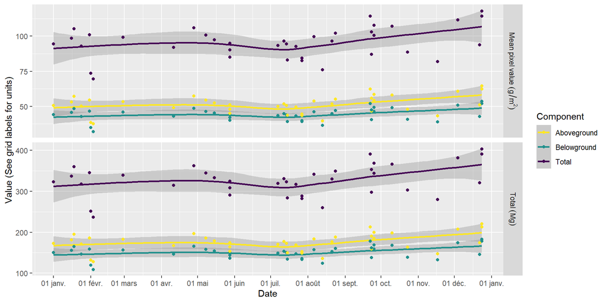

Figure 6.1: Predicted biomass values of the aboveground, belowground and total components of the seagrass meadows in Ria de Aveiro in the years 2024 and 2025.

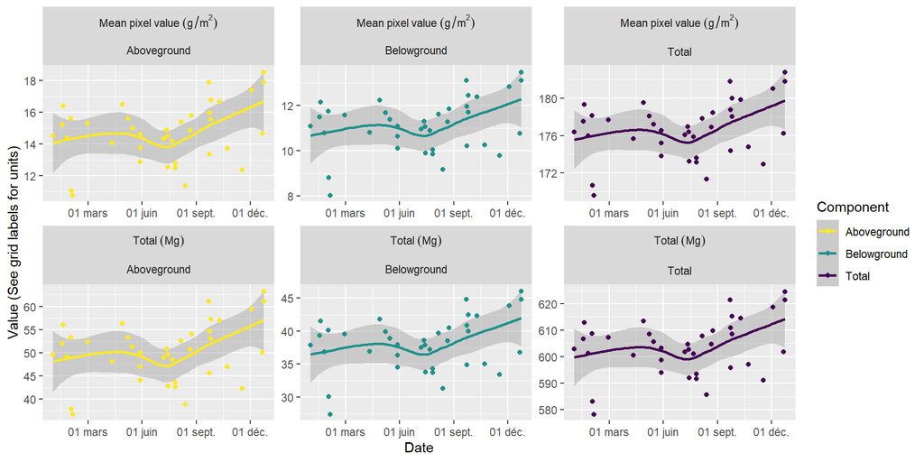

Figure 6.2: Predicted carbon values of the aboveground and belowground components of the seagrass meadows in Ria de Aveiro in the years 2024 and 2025. The total carbon estimate included the aboveground carbon estimate, belowground carbon estimate and the soil carbon estimate. The soil carbon estimate was extracted from the soil carbon stock per area for July 2025 reported in Sousa et al. (2019), which was based on the top 10 cm sediment layer.

# Reference

Davies, Bede Ffinian Rowe, Simon Oiry, Philippe Rosa, Maria Laura Zoffoli, Ana I. Sousa, Oliver R. Thomas, Dan A. Smale, et al. 2024. “Intertidal Seagrass Extent from Sentinel-2 Time-Series Show Distinct Trajectories in Western Europe.” *Remote Sensing of Environment* 312: 114340. https://doi.org/10.1016/j.rse.2024.114340.

R Core Team. 2025. *R: A Language and Environment for Statistical Computing*. Vienna, Austria: R Foundation for Statistical Computing. https://www.R-project.org/.

Sousa, Ana I, Jose Figueiredo da Silva, Ana Azevedo, and Ana I Lillebø. 2019. “Blue Carbon Stock in Zostera Noltei Meadows at Ria de Aveiro Coastal Lagoon (Portugal) over a Decade.” *Scientific Reports* 9 (1): 14387. https://doi.org/https://doi.org/10.1038/s41598-019-50425-4.